# Seaborn Workbook

Welcome to the Seaborn Workbook. Let’s start with importing the required libraries.

```python
import numpy as np
import pandas as pd
import seaborn as sns
import matplotlib.pyplot as plt
```

```python
%matplotlib notebook
```

Are you ready to prepare the best plots EVER? Let’s start with working on real data.

```python
# Read the iris dataset from a CSV file
iris_df = pd.read_csv('./iris.csv')

# Print data type for df
print( type(iris_df) )
```

```
<class 'pandas.core.frame.DataFrame'>
```

```python
iris_df.head()
```

|  | sepal_length | sepal_width | petal_length | petal_width | species |
| --- | --- | --- | --- | --- | --- |
| 0 | 5.1 | 3.5 | 1.4 | 0.2 | setosa |
| 1 | 4.9 | 3.0 | 1.4 | 0.2 | setosa |
| 2 | 4.7 | 3.2 | 1.3 | 0.2 | setosa |
| 3 | 4.6 | 3.1 | 1.5 | 0.2 | setosa |
| 4 | 5.0 | 3.6 | 1.4 | 0.2 | setosa |

If you want to explore different data sets, seaborn comes with default examples.

```python
iris_df = sns.load_dataset("iris")
```

### Lmplot and Regplot

These are the most simple plotting options for regression.

```python
sns.lmplot(x='sepal_length', y='sepal_width', data=iris_df)
plt.show()
```

[output not shown]

However, if you want to control the size and shape of the plot, you need to use regplot.

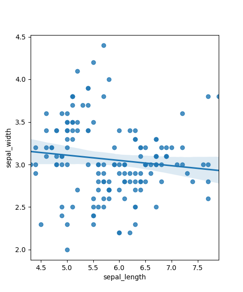

```python
fig, ax = plt.subplots(figsize=(5,6))
sns.regplot(x="sepal_length", y="sepal_width", data=iris_df, ax=ax)
```

### Relplot

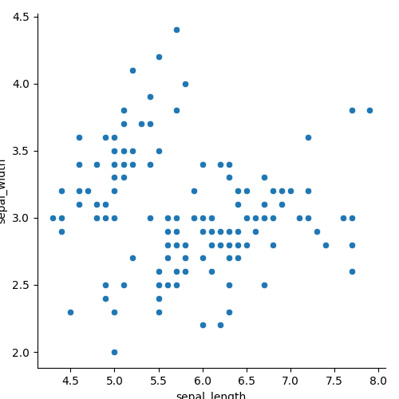

```python
fig = sns.relplot(data=iris_df, x="sepal_length", y="sepal_width")
plt.show()
```

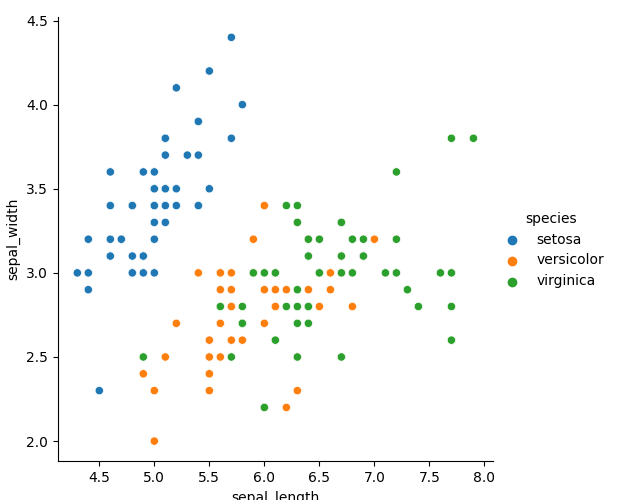

```python
sns.relplot(data=iris_df, x="sepal_length", y="sepal_width", hue='species')
plt.show()
```

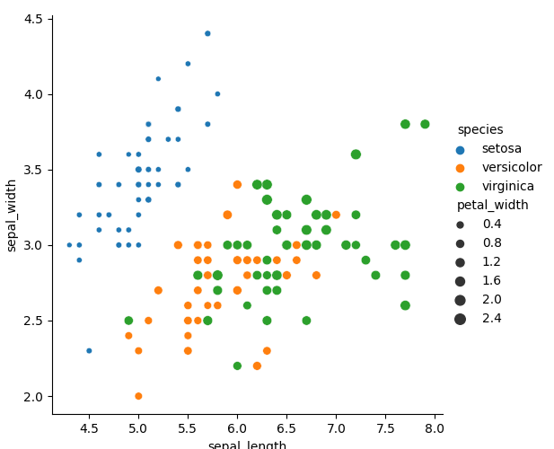

```python
sns.relplot(data=iris_df, x="sepal_length", y="sepal_width", hue='species', size="petal_width")
plt.show()
```

What can you tell me about these species?

### Jointplot

This plot type is used to plot two variables with bivariate and univariate graphs.

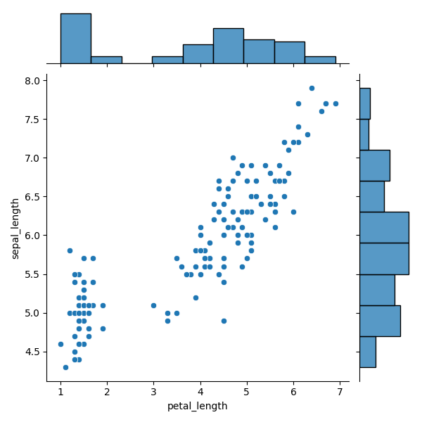

```python
sns.jointplot(data=iris_df, x="petal_length", y="sepal_length")
```

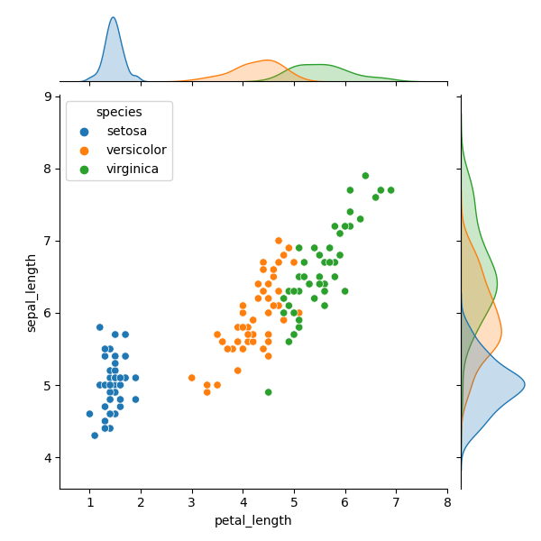

```python
sns.jointplot(data=iris_df, x="petal_length", y="sepal_length", hue="species")
```

### Pairplot

It explores the pairwise relationship of the whole data set.

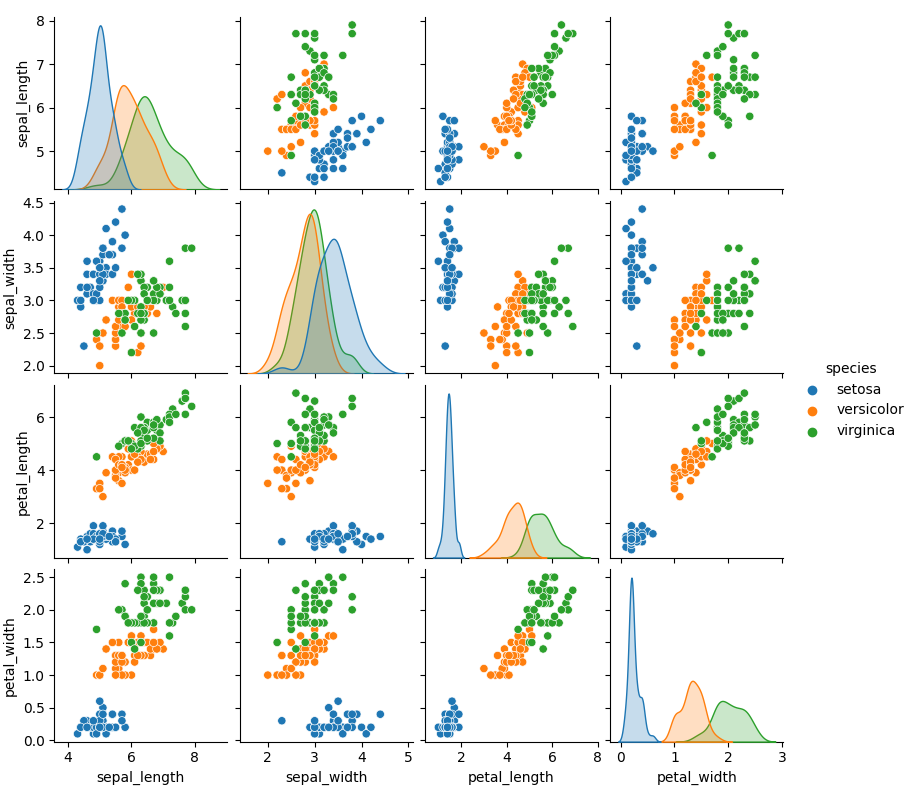

```python
sns.pairplot(data=iris_df, hue="species", height=2.)
plt.show()
```

### Countplot

Countplot is like a simple bar plot that shows the counts of observations in each category.

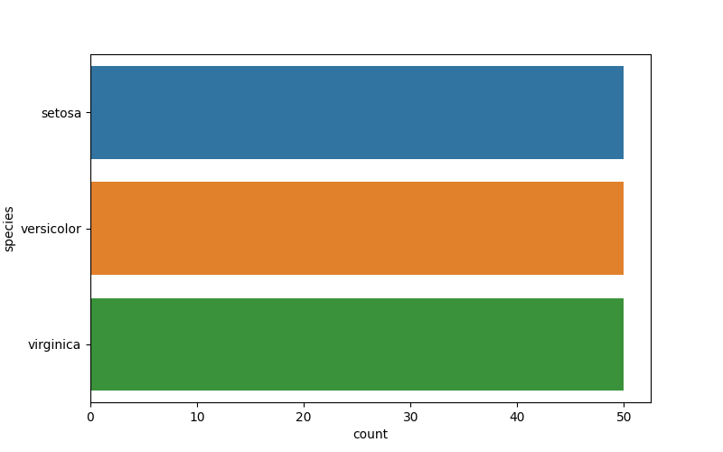

```python
fig, ax = plt.subplots(figsize=(8,5))
sns.countplot(y='species', data=iris_df)
plt.show()
```

### Boxplot and Violinplot

Boxplot shows the distributions with respect to categories as a box plot.  
Violinplot is a combination of boxplot and densities of categories.

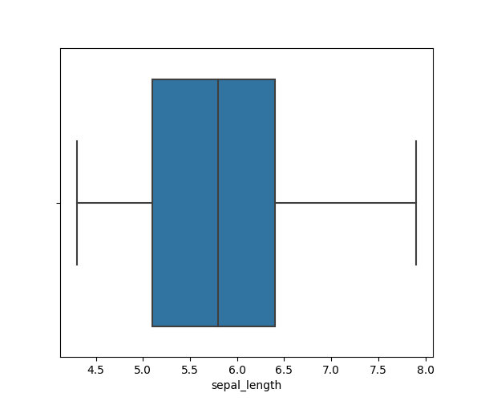

```python
fig, ax = plt.subplots(figsize=(6,5))
sns.boxplot(x='sepal_length', data=iris_df)
plt.show()
```

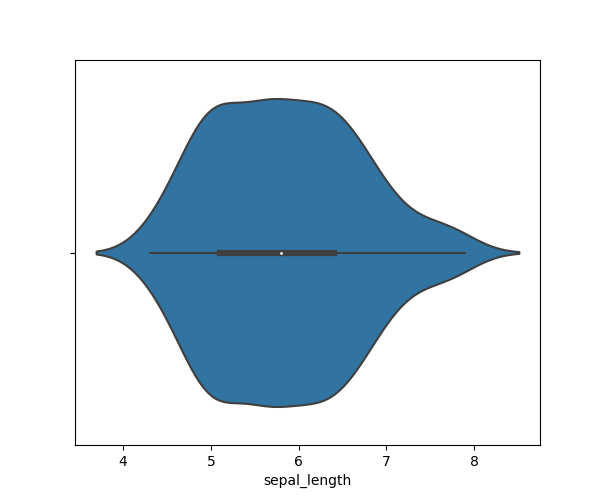

```python
fig, ax = plt.subplots(figsize=(6,5))
sns.violinplot(x='sepal_length', data=iris_df)
plt.show()
```

### Heatmap

A personal favourite, the heatmap is a rectangular matrix like demonstration of values.

```python
corr = iris_df.corr()
```

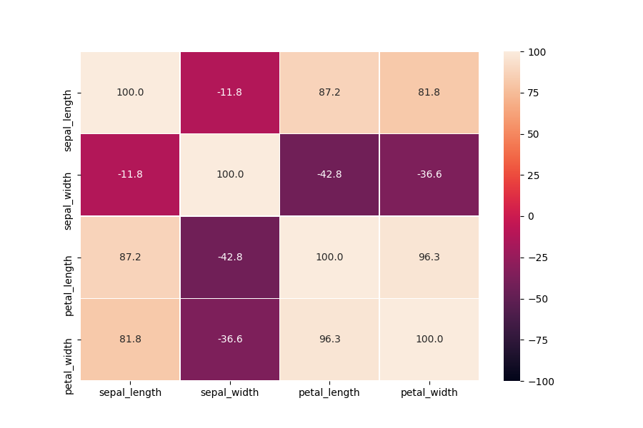

```python
# Draw a heatmap with the numeric values in each cell
f, ax = plt.subplots(figsize=(9, 6))
sns.heatmap(corr*100, annot=True, fmt="2.1f", linewidths=.5, ax=ax, vmin=-100)
plt.show()
```

👏 Congratulations, you have completed the Seaborn Workbook!